# Intro to Twitter Sentiment Analysis

# Overview

Use twitteR package to load tweets with #cilantro and #coriander - a divisive topic. Analyse sentiments using 3 new packages and 5 new functions:

- Connect to Twitter: `ROAuth`
  - `setup_twitter_oauth()`
- Scrape Twitter: `twitteR`
  - `searchTwitter()`
  - `twListToDF()`
- Sentiment analysis: `syuzhet`
  - `get_nrc_sentiment()`
  - `get_tokens()`

Some knowledge of regular expressions will also help, but only base functions are used.

# Load packages

```r
library(devtools)
# install.packages("ROAuth")
# install.packages('httr')
# devtools::install_github("geoffjentry/twitteR")
library(twitteR)
library(ROAuth) #for authentication with twitter server
library(magrittr)
library(dplyr)
library(readr)
library(ggplot2)

#library of sentiments for words
# install.packages('syuzhet')
library(syuzhet)
```

## Create Twitter App and connect inside R

- These steps are from [rStatistics.net](http://rstatistics.net/extracting-tweets-with-r/)
- First, go to https://apps.twitter.com/.
- Set up an app
- Click on Keys and Access Tokens tab
- record for later tweet uses as file in *private* folder
- Authenticate via R

This step uses only one function from the `ROAuth` package: * `setup_twitter_oauth()`

```r
if(.Platform$OS.type == 'windows'){
        keys <- read_csv('C:/Users/n9232371/OneDrive/shared files/Statslearningcourse/twitteR/keys.csv')

} else{
        keys <- read_csv('/Users/yam/OneDrive/shared files/Statslearningcourse/twitteR/keys.csv')

}

# setup_twitter_oauth(consumerKey, consumerSecret, accessToken, accessTokenSecret)

setup_twitter_oauth(keys$key[1],
                    keys$key[2],
                    keys$key[3],
                    keys$key[4])
```

```
## [1] "Using direct authentication"
```

## General Commands for `twitteR` package

Tweets from a user or your own account:

```
userTimeline('r_programmer',n=10) # tweets from a user

homeTimeline(n=15) # get tweets from your home timeline

mentions(n=15) # get your tweets that were retweeted

favs <- favorites("r_programmer", n =10) # tweets a user has favorited
```

Tweets with a particular hashtag or word

```
tweets <- searchTwitter("rstats", n=25) # top 25 tweets that contain search term

tweetsDF <- twListToDF(tweets) # more info about tweets - converts to nice df
```

## Scrape Tweets and Clean

I want any tweets that contain ‘coriander’ or ‘cilantro’. Cilantro is American for coriander :)

Extract tweets and convert to a nice dataframe using only two functions from `twitteR`:

- `searchTwitter()`
- `twListToDF()`

```r
tweets <- searchTwitter(c("coriander|cilantro"),
                        n=800, lang = "en")
head(tweets, 3)
```

```
## [[1]]
## [1] "jessnash_: @_vanessagomz oo next time we're high let's eat a cilantro salad since we are trying to be healthy"
##
## [[2]]
## [1] "Ajilityfitness: Yummy nutrious dinner for the win. Ground turkey, fresh tomatoes, jalapenos, cilantro, fresh https://t.co/jSAu4wuVI9"
##
## [[3]]
## [1] "ka_sael: https://t.co/Q2MFG39Qal I'm dead serious"
```

```r
# extract more info about tweets and convert to a nice df
tweetsDF <- twListToDF(tweets)

tweetsDF <- tweetsDF %>% select(text, favorited, favoriteCount, created, retweetCount, retweeted, screenName)

str(tweetsDF)
```

```
## 'data.frame':    800 obs. of  7 variables:
##  $ text         : chr  "@_vanessagomz oo next time we're high let's eat a cilantro salad since we are trying to be healthy" "Yummy nutrious dinner for the win. Ground turkey, fresh tomatoes, jalapenos, cilantro, fresh https://t.co/jSAu4wuVI9""| __truncated__ "https://t.co/Q2MFG39Qal I'm dead seri…
##  $ favorited    : logi  FALSE FALSE FALSE FALSE FALSE FALSE ...
##  $ favoriteCount: num  0 0 1 0 0 1 0 0 0 0 ...
##  $ created      : POSIXct, format: "2016-08-04 02:08:37" "2016-08-04 02:07:51" ...
##  $ retweetCount : num  0 0 0 1 0 0 1 0 0 0 ...
##  $ retweeted    : logi  FALSE FALSE FALSE FALSE FALSE FALSE ...
##  $ screenName   : chr  "jessnash_" "Ajilityfitness" "ka_sael" "YuTTyu1" ...
```

Clean up the text column to remove hashtags, urls, and punctuation. This section uses base functions:

- `gsub()`
- `iconv()`
- `grepl()`

```r
text.clean <- function(x) {

  x = gsub('http\\S+\\s*', '', x) ## Remove URLs

  x = gsub('\\b+RT', '', x) ## Remove RT

  x = gsub('#', '', x) ## Remove Hashtags

  x = gsub('@\\S+', '', x) ## Remove Mentions

  x = gsub('[[:cntrl:]]', '', x) ## Remove Controls and special characters

  x = gsub('&amp', 'and', x) ## Remove Controls and special characters

  x = gsub('[,.:;+-]|\\[|\\]|\\/', ' ', x) ## space replaces some Punctuation

  x = gsub('[[:punct:]]', '', x) ## Remove Punctuations

  x = gsub("^[[:space:]]*","",x) ## Remove leading whitespaces

  x = gsub("[[:space:]]*$","",x) ## Remove trailing whitespaces

  x = gsub(' +',' ',x) ## Remove extra whitespaces

  return(x)

}


tweetsDF$text <- text.clean(tweetsDF$text)

# use iconv function to convert character vector between encodings
tweetsDF$text <- iconv(tweetsDF$text, from = "latin1", to = "ASCII", sub = "byte")

# insert space before '<' and after '>' if it is next to a word
tweetsDF$text  <- gsub('([[:alpha:]])([<])', '\\1 \\2', tweetsDF$text )
tweetsDF$text  <- gsub('([>])([[:alpha:]])', '\\1 \\2', tweetsDF$text )

# remove any tweets without cilantro or coriander
tweetsDF <- tweetsDF[grepl("cilantro|coriander", tweetsDF$text, ignore.case = TRUE),]

# remove duplicates
tweetsDF <- tweetsDF[!duplicated(tweetsDF$text),]

#after cleaning
head(tweetsDF$text)
```

```
## [1] "oo next time were high lets eat a cilantro salad since we are trying to be healthy"
## [2] "Yummy nutrious dinner for the win Ground turkey fresh tomatoes jalapenos cilantro fresh <e2><80><a6>"
## [3] "Literally so obsessed with this Cabernet fresh jalape <c3><b1> o cilantro ched sour cream Ruffles mix I have going on right no <e2><80><a6>"
## [4] "no I had to put cilantro out"
## [5] "Steak tacos with green peppers yellow peppers onions cilantro aguacate Mexican cream and queso blanco"
## [6] "Chicken soup with fennel leek celery radishes cilantro etc etc"
```

## Sentiment Analysis

I lifted this code from a blog by Julia Silge http://juliasilge.com/blog/Joy-to-the-World/

She uses the ‘syuzhet’ package developed in Stanford by Saif Mohammad and Peter Turney. They used the NRC Word-Emotion Association Lexicon to build a dictionary of words with scores for eight different emotions and two sentiments. Not every English word is included because most are neutral.

We will use the following functions from the `syuzhet` package:

- `get_nrc_sentiment()`
- `get_tokens()`

### Example Single Tweet

```r
get_nrc_sentiment("Tonights dinner menu my famous green chili lemon cilantro chicken enchiladas Time to roll some fat ones")
```

```
##   anger anticipation disgust fear joy sadness surprise trust negative
## 1     0            1       2    1   1       1        0     1        2
##   positive
## 1        3
```

```r
token.sent <- function(x){
        output <- vector(mode = "list", length = length(x))

        for(i in seq_along(x)){
                by.word <- data_frame("token" = get_tokens(x[i]))
                by.word <- cbind(by.word, get_nrc_sentiment(by.word$token))
                #filter for rows with entries greater than 0:
                output[[i]] <- by.word[rowSums(by.word %>% select(-token)) != 0,]
        }

        names(output) = x
        return(output)
}

token.sent("Tonights dinner menu my famous green chili lemon cilantro chicken enchiladas Time to roll some fat ones")
```

```
## $`Tonights dinner menu my famous green chili lemon cilantro chicken enchiladas Time to roll some fat ones`
##      token anger anticipation disgust fear joy sadness surprise trust
## 2   dinner     0            0       0    0   0       0        0     0
## 5   famous     0            0       0    0   0       0        0     0
## 6    green     0            0       0    0   1       0        0     1
## 8    lemon     0            0       1    0   0       0        0     0
## 10 chicken     0            0       0    1   0       0        0     0
## 12    time     0            1       0    0   0       0        0     0
## 16     fat     0            0       1    0   0       1        0     0
##    negative positive
## 2         0        1
## 5         0        1
## 6         0        1
## 8         1        0
## 10        0        0
## 12        0        0
## 16        1        0
```

## Apply sentiment analysis to all tweets

```r
sents = get_nrc_sentiment(tweetsDF$text)

tweetsDF <- cbind(tweetsDF, sents)
```

## Make a plot

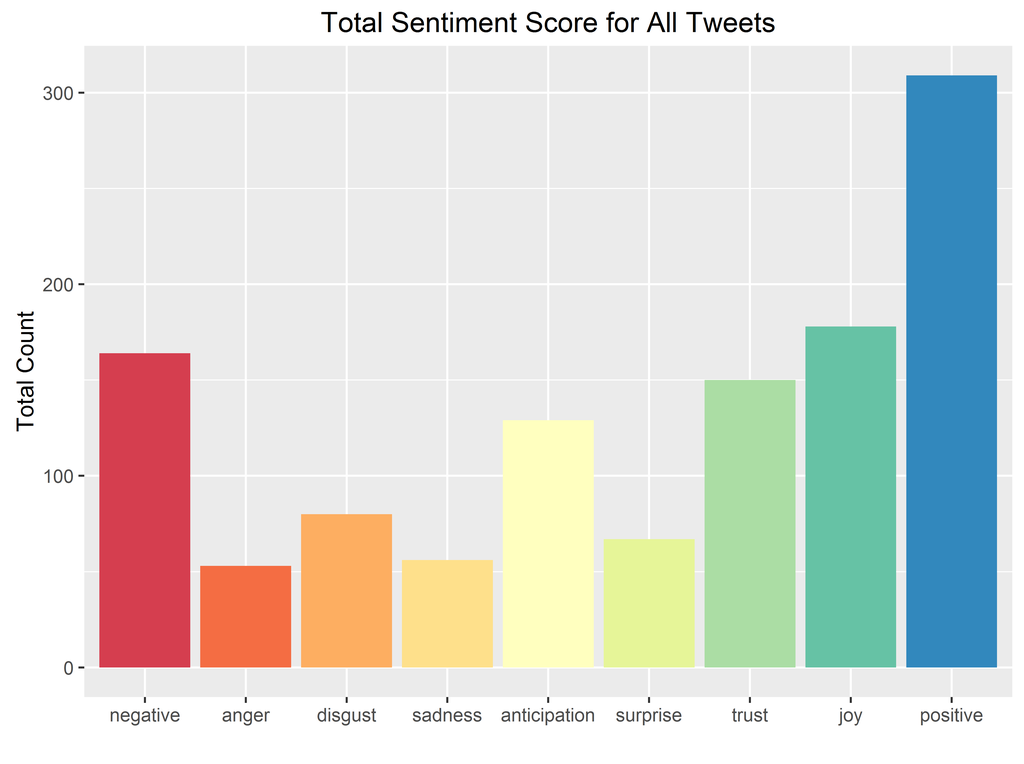

```r
sents <- c('negative', 'anger','disgust','sadness','anticipation','surprise','trust','joy','positive')

plot.df <- data.frame("count" = colSums(tweetsDF[, sents]),
                              "sentiment" = sents)
#reorder levels
plot.df$sentiment <- factor(plot.df$sentiment, levels= sents)

ggplot(plot.df, aes(x = sentiment, y = count)) +
        geom_bar(aes(fill = sentiment), stat = "identity") +
        theme(legend.position = "none") +
        xlab("") + ylab("Total Count") + ggtitle("Total Sentiment Score for All Tweets") +
        scale_fill_brewer(palette = "Spectral")
```

## Investigate

Highest sentiment tweets

```r
sent.summary <- function(sentiment = "positive", df = tweetsDF, n = 3){
        temp <- df[order(-df[,sentiment]),] %>% slice(1:n)

        top.n <- token.sent(temp$text)

        print(temp[,c(sentiment)])
        print(
                top.n
        )

}

sent.summary("disgust")
```

```
## [1] 3 3 2
## $`It <e2><80><99> s hard for me to decide which I find more vomit inducing cilantro or curry How do people eat such disgusting shit`
##         token anger anticipation disgust fear joy sadness surprise trust
## 15      vomit     0            0       1    0   0       0        0     0
## 23        eat     0            0       0    0   0       0        0     0
## 25 disgusting     1            0       1    1   0       0        0     0
## 26       shit     1            0       1    0   0       0        0     0
##    negative positive
## 15        0        0
## 23        0        1
## 25        1        0
## 26        1        0
##
## $`cilantro gets sick and sign previously feeling indifferent to his rat fuck of a son Feels Fatherly Feelings`
##      token anger anticipation disgust fear joy sadness surprise trust
```

[output cut: 25 more lines]

```r
sent.summary("anticipation")
```

```
## [1] 3 2 2
## $`Lovely with a cilantro garnish for luck on the sour cream`
##      token anger anticipation disgust fear joy sadness surprise trust
## 1   lovely     0            1       0    0   1       1        1     1
## 5  garnish     0            0       0    0   0       0        0     0
## 7     luck     0            1       0    0   1       0        1     0
## 10    sour     0            0       1    0   0       0        0     0
## 11   cream     0            1       0    0   1       0        1     0
##    negative positive
## 1         0        1
## 5         1        0
## 7         0        1
## 10        1        0
## 11        0        1
##
## $`People always get excited when I tell them they can enjoy Cilantro Salmon and Peppers`
##      token anger anticipation disgust fear joy sadness surprise trust
## 4  excited     0            1       0    0   1       0        1     1
## 11   enjoy     0            1       0    0   1       0        0     1
##    negative positive
## 4         0        1
## 11        0        1
##
## $`Paradise Roll Tuna Cream Cheese Cucumber Cilantro Jalapeno Sweet Soy wrapped in Tuna and <e2><80><a6>`
##   token anger anticipation disgust fear joy sadness surprise trust
## 4 cream     0            1       0    0   1       0        1     0
## 9 sweet     0            1       0    0   1       0        1     1
##   negative positive
## 4        0        1
## 9        0        1
```

```r
sent.summary("retweetCount")
```

```
## [1] 404 179 112
## $`Grilled Shrimp Tacos With Creamy Cilantro Sauce RECIPE`
##  [1] token        anger        anticipation disgust      fear
##  [6] joy          sadness      surprise     trust        negative
## [11] positive
## <0 rows> (or 0-length row.names)
##
## $`Ima name my son cilantro`
##  [1] token        anger        anticipation disgust      fear
##  [6] joy          sadness      surprise     trust        negative
## [11] positive
## <0 rows> (or 0-length row.names)
##
## $`Coriander Cats Bengali Girls in the Wild by Farah Billah`
##   token anger anticipation disgust fear joy sadness surprise trust
## 7  wild     0            0       0    0   0       0        1     0
##   negative positive
## 7        1        0
```

```r
sent.summary("favoriteCount")
```

```
## [1] 147  27  22
## $`if u dont like cilantro u are probably not enjoying mexican food and u are probably not enjoying indian food and u are def fucking up`
##       token anger anticipation disgust fear joy sadness surprise trust
## 10 enjoying     0            1       0    0   1       0        0     1
## 12     food     0            0       0    0   1       0        0     1
## 18 enjoying     0            1       0    0   1       0        0     1
## 20     food     0            0       0    0   1       0        0     1
##    negative positive
## 10        0        1
## 12        0        1
## 18        0        1
## 20        0        1
##
## $`Cilantro does not taste like soap`
##  [1] token        anger        anticipation disgust      fear
##  [6] joy          sadness      surprise     trust        negative
## [11] positive
## <0 rows> (or 0-length row.names)
##
## $`Trying the carrot and coriander soup`
##   token anger anticipation disgust fear joy sadness surprise trust
## 6  soup     0            0       0    0   0       0        0     0
##   negative positive
## 6        0        1
```